# Exploration on Different Categories of Happy Moments

## *Yiyang Zeng*

For this project, I would like to explore different categories of happy moments, what might be the main drivers for these categories and how are categories different from each other.

The source of the dataset comes from a corpus of 100,000 crowd-sourced happy moments via Amazon's Mechanical Turk. Detailed information about the dataset is on https://rit-public.github.io/HappyDB/.

## Step 0: Load All the Packages

Brief descriptions are as following:

Pandas: **pandas** is a Python package providing fast, flexible, and expressive data structures designed to make working with "relational" or "labeled" data both easy and intuitive.

Numpy: **numpy** is a package providing an array object of arbitrary homogeneous items, fast mathematical operations over arrays and linear algebra, fourier transforms, random number generation.

PIL: **PIL** isa package for working with images.

Matplotlib.pyploy: **matplotlib.pyplot** is a state-based interface to matplotlib. It provides a MATLAB-like way of plotting. Pyplot is mainly intended for interactive plots and simple cases of programmatic plot generation.

wordcloud: **wordcloud** is a package for generating wordclous.

gensim: **gensim** contains interfaces and functionality to compute pair-wise document similarities within a corpus of documents.

seaborn: **seaborn** is a Python data visualization library based on matplotlib. It provides a high-level interface for drawing attractive and informative statistical graphics.

```python
import pandas as pd
from pandas import DataFrame
pd.set_option('display.max_columns', 50)
import numpy as np
from PIL import Image
import PIL
import matplotlib.pyplot as plt
%matplotlib inline
from wordcloud import WordCloud, STOPWORDS
import gensim
from gensim import corpora,models
from gensim.models import LdaModel
from gensim.parsing.preprocessing import remove_stopwords,strip_punctuation, strip_numeric,strip_short
import seaborn as sns
```

## Step 1: Load the Dataset

The dataset I will be using is called processed_moments.csv. It is a preprocessed version of the HappyDB dataset, created by Arpita Shah and Tian Zheng. Some of the more important columns for this project are cleaned_hm, predicted_category and text.

cleaned_hm: This is the cleaned version of the happy moments written by people.

predicted_category: This is the predicted category of the happy moments and it is the most important thing that I care about in this project.

text: This is the lists of informative words extracted from cleaned_hm.

```python
# processed_moments is under data folder
df = pd.read_csv("processed_moments.csv")
df
```

|  | hmid | wid | reflection_period | original_hm | cleaned_hm | modified | num_sentence | ground_truth_category | predicted_category | id | text |
| --- | --- | --- | --- | --- | --- | --- | --- | --- | --- | --- | --- |
| 0 | 27673 | 2053 | 24h | I went on a successful date with someone I fel... | I went on a successful date with someone I fel... | True | 1 | NaN | affection | 1 | successfully date sympathy connected |
| 1 | 27674 | 2 | 24h | I was happy when my son got 90% marks in his e... | I was happy when my son got 90% marks in his e... | True | 1 | NaN | affection | 2 | son marks examination |
| 2 | 27675 | 1936 | 24h | I went to the gym this morning and did yoga. | I went to the gym this morning and did yoga. | True | 1 | NaN | exercise | 3 | gym morning yoga |
| 3 | 27676 | 206 | 24h | We had a serious talk with some friends of our... | We had a serious talk with some friends of our... | True | 2 | bonding | bonding | 4 | talked friend flaky understood evening hang |
| 4 | 27677 | 6227 | 24h | I went with grandchildren to butterfly display... | I went with grandchildren to butterfly display... | True | 1 | NaN | affection | 5 | grandchildren butterfly display crohn conserva... |
| 5 | 27678 | 45 | 24h | I meditated last night. | I meditated last night. | True | 1 | leisure | leisure | 6 | meditation night |
| 6 | 27679 | 195 | 24h | I made a new recipe for peasant bread, and it ... | I made a new recipe for peasant bread, and it ... | True | 1 | NaN | achievement | 7 | recipe peasant bread spectacular |
| 7 | 27680 | 740 | 24h | I got gift from my elder brother which was rea... | I got gift from my elder brother which was rea... | True | 1 | NaN | affection | 8 | gift elderly brother surprise |
| 8 | 27681 | 3 | 24h | YESTERDAY MY MOMS BIRTHDAY SO I ENJOYED | YESTERDAY MY MOMS BIRTHDAY SO I ENJOYED | True | 1 | NaN | enjoy_the_moment | 9 | mom birthday enjoyed |
| 9 | 27682 | 4833 | 24h | Watching cupcake wars with my three teen children | Watching cupcake wars with my three teen children | True | 1 | NaN | affection | 10 | watched cupcakes wars teen children |
| 10 | 27683 | 7334 | 24h | I came in 3rd place in my Call of Duty video g... | I came in 3rd place in my Call of Duty video g... | True | 1 | NaN | leisure | 11 | called duty video game |
| 11 | 27684 | 78 | 24h | I completed my 5 miles run without break. It m... | I completed my 5 miles run without break. It m... | True | 2 | NaN | exercise | 12 | completed miles run break makes feel strong |
| 12 | 27685 | 21 | 24h | went to movies with my friends it was fun | went to movies with my friends it was fun | True | 1 | NaN | bonding | 13 | movie friend fun |
| 13 | 27686 | 8 | 24h | I was shorting Gold and made $200 from the trade. | I was shorting Gold and made $200 from the trade. | True | 1 | NaN | achievement | 14 | short gold trade |
| 14 | 27687 | 586 | 24h | Hearing Songs It can be nearly impossible to g... | Hearing Songs It can be nearly impossible to g... | False | 2 | NaN | enjoy_the_moment | 15 | hear song impossible angry youre ease angry fe... |
| 15 | 27688 | 489 | 24h | My son performed very well for a test preparat... | My son performed very well for a test preparat... | True | 1 | NaN | affection | 16 | son performance test prepared |
| 16 | 27689 | 976 | 24h | I helped my neighbour to fix their car damages. | I helped my neighbour to fix their car damages. | True | 1 | NaN | bonding | 17 | helped neighbours fixed car damage |
| 17 | 27690 | 3972 | 24h | Managed to get the final trophy in a game I wa... | Managed to get the final trophy in a game I wa... | True | 1 | NaN | achievement | 18 | managed finally trophy game played |
| 18 | 27691 | 14 | 24h | A hot kiss with my girl friend last night made... | A hot kiss with my girl friend last night made... | True | 1 | NaN | bonding | 19 | hot kiss girl friend night day |
| 19 | 27692 | 1230 | 24h | My new BCAAs came in the mail. Yay! Strawberry... | My new BCAAs came in the mail. Yay! Strawberry... | True | 3 | NaN | affection | 20 | bcaa mail yay strawberry lemonade flavor amino... |
| 20 | 27693 | 9950 | 24h | Got A in class. | Got A in class. | True | 1 | NaN | achievement | 21 | class |
| 21 | 27694 | 4862 | 24h | My sister called me from abroad this morning a... | My sister called me from abroad this morning a... | True | 2 | NaN | affection | 22 | sister called abroad morning occassion family |
| 22 | 27695 | 4891 | 24h | The cake I made today came out amazing. It tas... | The cake I made today came out amazing. It tas... | True | 2 | NaN | achievement | 23 | cake amazing tasted amazing |
| 23 | 27696 | 737 | 24h | There are two types of people in the world: th... | There are two types of people in the world: th... | False | 2 | NaN | enjoy_the_moment | 24 | type people world choose choose unhappy contra... |
| 24 | 27697 | 498 | 24h | My grandmother start to walk from the bed afte... | My grandmother start to walk from the bed afte... | True | 1 | affection | affection | 25 | grandmother started walk bed time |
| 25 | 27698 | 2124 | 24h | i was able to hit a top spin serve in tennis | i was able to hit a top spin serve in tennis | True | 1 | NaN | achievement | 26 | hit top spin served tennis |
| 26 | 27699 | 156 | 24h | I napped with my husband on the bed this after... | I napped with my husband on the bed this after... | True | 1 | NaN | affection | 27 | nap husband bed afternoon sweet cuddled close |
| 27 | 27700 | 1783 | 24h | My co-woker started playing a Carley Rae Jepse... | My co-woker started playing a Carley Rae Jepse... | True | 1 | NaN | leisure | 28 | cowoker started played carley rae jepsen song ... |
| 28 | 27701 | 3382 | 24h | My son woke me up to a fantastic breakfast of ... | My son woke me up to a fantastic breakfast of ... | True | 1 | NaN | affection | 29 | son woke fantastic breakfast eggs special hamb... |
| 29 | 27702 | 54 | 24h | After a long time my brother gave a suprise vi... | After a long time my brother gave a suprise vi... | True | 1 | NaN | affection | 30 | time brother suprise visit house |
| ... | ... | ... | ... | ... | ... | ... | ... | ... | ... | ... | ... |
| 100362 | 128737 | 1161 | 24h | DRY DAY CELEBRATION | DRY DAY CELEBRATION | True | 1 | NaN | achievement | 100506 | dry day celebrated |
| 100363 | 128738 | 2780 | 24h | My bills were paid on time | My bills were paid on time | True | 1 | NaN | achievement | 100507 | bill paid time |
| 100364 | 128739 | 2545 | 24h | I watched my favorite gamer on Twitch.tv and h... | I watched my favorite gamer on Twitch.tv and h... | True | 1 | NaN | leisure | 100508 | watched favorite gamer twitchtv hilarious |
| 100365 | 128740 | 10983 | 24h | I was able to accomplish one of my goals at wo... | I was able to accomplish one of my goals at wo... | True | 1 | NaN | achievement | 100509 | accomplished goal customer thanked profusely |
| 100366 | 128741 | 3948 | 24h | I heard a song I really like on the radio this... | I heard a song I really like on the radio this... | True | 1 | NaN | enjoy_the_moment | 100510 | heard song radio morning coffee |
| 100367 | 128742 | 525 | 24h | A friend called just to see how i'd been doing. | A friend called just to see how i'd been doing. | True | 1 | NaN | bonding | 100511 | friend called id |
| 100368 | 128743 | 13605 | 24h | Last night while attending my grandmother's wa... | Last night while attending my grandmother's wa... | True | 1 | NaN | bonding | 100512 | night attended grandmother wake enjoyed friend... |
| 100369 | 128744 | 5180 | 24h | My friend came to my home and he give some gif... | My friend came to my home and he give some gif... | True | 1 | NaN | bonding | 100513 | friend home gift energy project |
| 100370 | 128745 | 1234 | 24h | I went shopping for Father's Day dinner on Sun... | I went shopping for Father's Day dinner on Sun... | True | 1 | NaN | affection | 100514 | shopping father day dinner sunday |
| 100371 | 128746 | 248 | 24h | I woke up in the middle of the night and reali... | I woke up in the middle of the night and reali... | True | 1 | enjoy_the_moment | enjoy_the_moment | 100515 | woke middle night realized hours sleep left |
| 100372 | 128747 | 2974 | 24h | I had pizza for dinner and it was great | I had pizza for dinner and it was great | True | 1 | NaN | enjoy_the_moment | 100516 | pizza dinner |
| 100373 | 128748 | 8880 | 24h | My husband called me just to tell me he loved me. | My husband called me just to tell me he loved me. | True | 1 | NaN | affection | 100517 | husband called love |
| 100374 | 128749 | 2616 | 24h | I was able to weed my entire garden and plant ... | I was able to weed my entire garden and plant ... | True | 1 | NaN | nature | 100518 | weed entire garden planted tomato basil rain |
| 100375 | 128750 | 323 | 24h | A coworker praised the job I did on a recent p... | A coworker praised the job I did on a recent p... | True | 1 | NaN | achievement | 100519 | coworker praised job recently project supervisor |
| 100376 | 128751 | 11402 | 24h | Fixed my car. | Fixed my car. | True | 1 | NaN | achievement | 100520 | fixed car |
| 100377 | 128752 | 301 | 24h | I had a little time to myself in the afternoon. | I had a little time to myself in the afternoon. | True | 1 | NaN | enjoy_the_moment | 100521 | time afternoon |
| 100378 | 128753 | 597 | 24h | I worked out, which always makes me feel good. | I worked out, which always makes me feel good. | True | 1 | NaN | enjoy_the_moment | 100522 | makes feel |
| 100379 | 128754 | 105 | 24h | Finally got to watch the new Resident Evil movie. | Finally got to watch the new Resident Evil movie. | True | 1 | NaN | leisure | 100523 | finally watched residence evil movie |
| 100380 | 128755 | 22 | 24h | I made plans to go to a new restaurant with th... | I made plans to go to a new restaurant with th... | True | 1 | NaN | bonding | 100524 | planned restaurant friend havent |
| 100381 | 128756 | 412 | 24h | Those rare, perfectly timed naps that leave yo... | Those rare, perfectly timed naps that leave yo... | True | 3 | NaN | achievement | 100525 | rare perfect time nap leave feel refreshed gro... |
| 100382 | 128757 | 1767 | 24h | I got to talk to an old friend and reminisce o... | I got to talk to an old friend and reminisce o... | True | 1 | NaN | bonding | 100526 | talked friend reminisce time |
| 100383 | 128758 | 4428 | 24h | Yesterday my relations came to my house. That ... | Yesterday my relations came to my house. That ... | True | 2 | affection | affection | 100527 | relatives house time |
| 100384 | 128759 | 11050 | 24h | I am fond of seeing cricket match. Yesterday t... | I am fond of seeing cricket match. Yesterday t... | True | 6 | NaN | enjoy_the_moment | 100528 | fond cricket match semi finally champions trop... |
| 100385 | 128760 | 5 | 24h | My daughter made a very funny sound when I was... | My daughter made a very funny sound when I was... | True | 1 | NaN | affection | 100529 | daughter funny sound change diaper night laugh |
| 100386 | 128761 | 4298 | 24h | I spent time with my daughter. | I spent time with my daughter. | True | 1 | NaN | affection | 100530 | spent time daughter |
| 100387 | 128762 | 112 | 24h | My husband announced he is getting a decent bo... | My husband announced he is getting a decent bo... | True | 1 | NaN | affection | 100531 | husband announced decent bonus quarter |
| 100388 | 128763 | 714 | 24h | Had a can of Pepsi to drink. | Had a can of Pepsi to drink. | True | 1 | NaN | enjoy_the_moment | 100532 | pepsi drink |
| 100389 | 128764 | 3934 | 24h | Cuddling with my girlfriend last night. | Cuddling with my girlfriend last night. | True | 1 | affection | affection | 100533 | cuddled girlfriend night |
| 100390 | 128765 | 1629 | 24h | I had a great meeting yesterday at work with m... | I had a great meeting yesterday at work with m... | True | 1 | NaN | bonding | 100534 | meet boss colleagues lunch afterward excited p... |
| 100391 | 128766 | 141 | 24h | I had a great workout last night. | I had a great workout last night. | True | 1 | NaN | exercise | 100535 | workout night |

100392 rows × 11 columns

## Step 2: Preliminary Data Exploration

df.info() enables us to take a closer look at the columns in the dataset as well as their data types.

```python
df.info()
```

```
<class 'pandas.core.frame.DataFrame'>
RangeIndex: 100392 entries, 0 to 100391
Data columns (total 11 columns):
hmid                     100392 non-null int64
wid                      100392 non-null int64
reflection_period        100392 non-null object
original_hm              100392 non-null object
cleaned_hm               100392 non-null object
modified                 100392 non-null bool
num_sentence             100392 non-null int64
ground_truth_category    14107 non-null object
predicted_category       100392 non-null object
id                       100392 non-null int64
text                     100391 non-null object
dtypes: bool(1), int64(4), object(6)
memory usage: 7.8+ MB
```

By the following function, we see there are **seven unique** categories of happy moments in the dataset.  
And they are: **affection, exercise, bonding, leisure, achievement, enjoy_the_moment and nature**.

```python
df["predicted_category"].unique()
```

```
array(['affection', 'exercise', 'bonding', 'leisure', 'achievement',
       'enjoy_the_moment', 'nature'], dtype=object)
```

## Step 3: A Look at the Number of Sentences by Categories

First, I would like to see the relationship between number of sentences and different categories of happy moments. Thus, I draw seven boxplots on one graph as following, and my findings are:

There are many outliers in terms of number of sentences in the dataset, which makes the boxplots hard to see.

Relatively speaking, the category exercise and leisure seem to be stable, in terms of number of sentences.

Enjoy_the_moment and affections have large ranges of number of sentences.

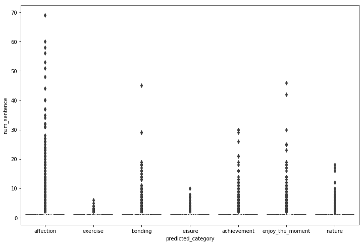

```python
plt.figure(figsize = (12,8))
ax = sns.boxplot(x="predicted_category", y="num_sentence", data=df)

# Calculate number of obs per group & median to position labels
medians = df.groupby(['predicted_category'])['num_sentence'].median().values
nobs = df['predicted_category'].value_counts().values
nobs = [str(x) for x in nobs.tolist()]
nobs = ["n: " + i for i in nobs]

pos = range(len(nobs))
for tick,label in zip(pos,ax.get_xticklabels()):
    ax.text(pos[tick], medians[tick] + 0.03, nobs[tick],
    horizontalalignment='center', size='x-small', color='w', weight='semibold')

plt.show()
```

To be able to better visualize the number of sentences by categories. I also calculate their means. From the following chart, we can see that average speaking:

Enjoy_the_moment has a mean of 1.48, the highest one out of seven. People like to talk more about enjoying certain moments.

Leisure only has a mean of 1.1, the lowest one out of seven. It might be hard for people to elaborate more on leisure, as most leisure activities can be easily described in less amounts of sentences.

```python
sen = df.groupby('predicted_category', as_index=False)['num_sentence'].mean()
sen
```

|  | predicted_category | num_sentence |
| --- | --- | --- |
| 0 | achievement | 1.227483 |
| 1 | affection | 1.460455 |
| 2 | bonding | 1.366959 |
| 3 | enjoy_the_moment | 1.483032 |
| 4 | exercise | 1.144649 |
| 5 | leisure | 1.100979 |
| 6 | nature | 1.319045 |

Using the means of number of sentences calculated above, I also draw its corresponding barplot below. The plot helps visualize the difference in means.

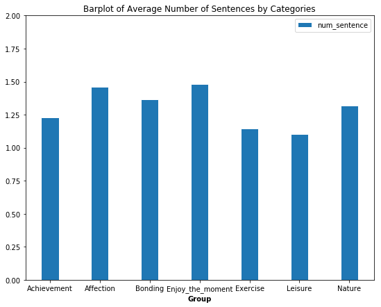

```python
bars1 = list(sen["num_sentence"])
plt.figure(figsize = (9,7))

# Set position of bar on X axis
r1 = np.arange(len(bars1))

# Make the plot
plt.bar(r1, bars1, width=0.35, edgecolor='white', label='num_sentence')

# Add xticks on the middle of the group bars
plt.xlabel('Group', fontweight='bold')
plt.xticks([r for r in range(len(bars1))], ['Achievement', 'Affection', 'Bonding', 'Enjoy_the_moment', 'Exercise', 'Leisure', 'Nature'])

# Create legend & Show graphic
plt.title("Barplot of Average Number of Sentences by Categories")
plt.ylim(0,2)
plt.legend()
plt.show()
```

## Step 4: Word Cloud

By common sense, I think the seven categories of happy moments should all contain different sets of frequent words, as they are describing different happy moments. Therefore, I decide to draw word clouds by seven categories to find some of the frequent words.  
I start by drawing a word cloud for the whole sample based on the text column of the data set. I feel the bigger words in the word cloud are either people ("friend", "family", "wife", "husband") or terms related to time("time", "finally", "first"):

When thinking about happy moments, people tend to think of some memorable events with people close to them, such as family, husband, wife, friend and so on.

Time is also important. Happy moments could be something people have done for the very first time or something they have been thinking about for long time.

*** I used a heart-shaped mask for all my word clouds, as I think a red heart can be a symbol of happiness. This mask image is under data folder.

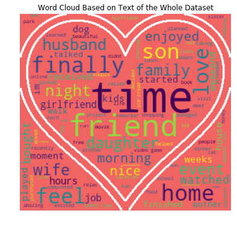

```python
#draw a word cloud based on the text column of the whole dataset
plt.figure(figsize = (8,6))
#happy.png is under data folder
heart = np.array(Image.open("C:/Users/zengy/Desktop/2019 Spring Semester/Applied Data Science/Project 1/happy.png"))
stopwords = set(STOPWORDS)
stopwords.update(["made","one", "day", "found"])
txt = " ".join(str(i) for i in df.text)
txt = txt.lower()
txt_wordcloud = WordCloud(stopwords=stopwords, background_color=(240,100,100), contour_width=2,
                           mask = heart, contour_color='white', max_words=100).generate(txt)
plt.imshow(txt_wordcloud, interpolation="bilinear")
plt.title("Word Cloud Based on Text of the Whole Dataset")
plt.axis('off')
plt.show()
```

I then write the word_cloud function as below to make it easier to draw word cloud for each category.

```python
def word_cloud(cate):
    plt.figure(figsize = (8,6))
    heart = np.array(Image.open("C:/Users/zengy/Desktop/2019 Spring Semester/Applied Data Science/Project 1/happy.png"))
    full_text = " ".join(str(i) for i in df[df['predicted_category'] == cate].text)
    full_text = full_text.lower()
    stopwords = set(STOPWORDS)
    stopwords.update(["made","one", "day", "found"])
    full_wordcloud = WordCloud(stopwords=stopwords, background_color=(240,100,100), contour_width=2,
                           mask = heart, contour_color='white', max_words=100).generate(full_text)
    plt.imshow(full_wordcloud, interpolation="bilinear")
    plt.title("Word Cloud of the " + cate + " Category")
    plt.axis('off')
    plt.figure(figsize = (12,9))
    plt.show()
```

Some of the findings for the seven categories:

achievement: working hard or studying hard are associated with achievement happy moments.

affection: things with family members or significant other are associated with affection happy moments.

bonding: bonding is more about happy moments with people other than family, and these people could be friends, colleagues or classmates.

enjoy_the_moment: enjoy_the_moment can be a lot of different things. People however have a tendency to associate the moment with enojying food.

exercise: exercise happy moments are pretty straightforward. The most frequent words are associated with running, going to gym or some other exercise.

leisure: people like to mention movies, video games or vacation for leisure. These are possibly the most popular ways of leisure.

nature: nature happy moments are about observing natural objects or natural environment. It is straightforward as well.

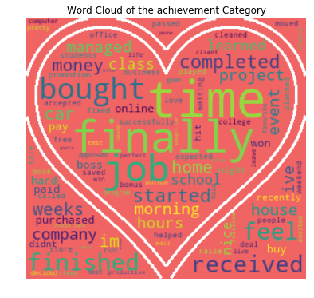

```python
word_cloud('achievement')
```

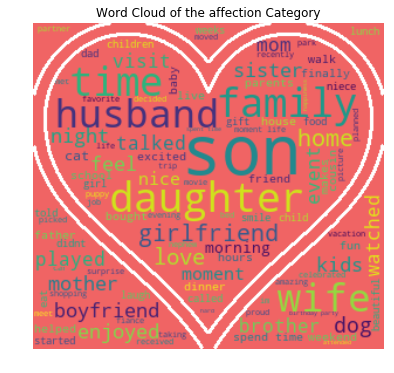

```python
word_cloud('affection')
```

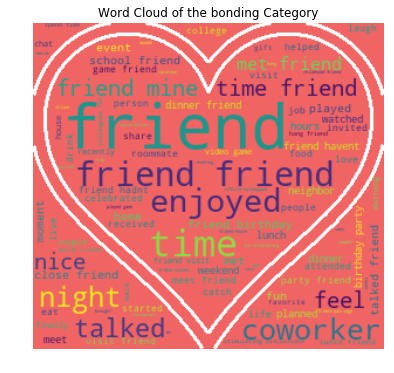

```python
word_cloud('bonding')
```

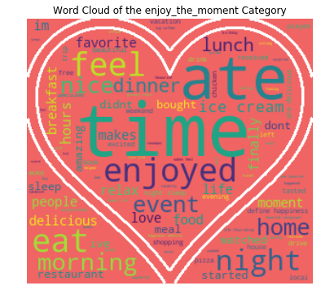

```python
word_cloud('enjoy_the_moment')
```

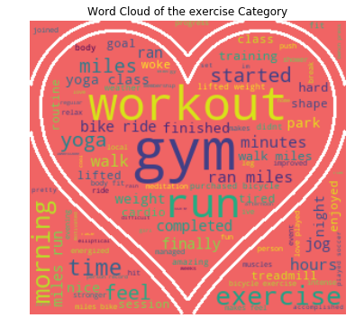

```python
word_cloud('exercise')
```

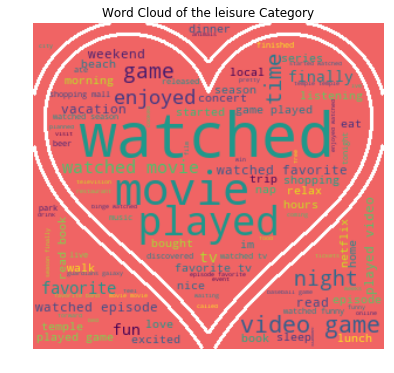

```python
word_cloud('leisure')
```

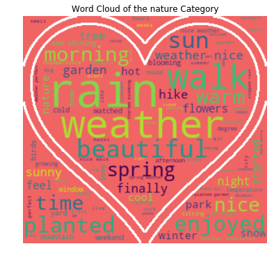

```python
word_cloud('nature')
```

## Step 5: Sentiment Analysis

```python
#read nrc data used for sentiment analysis
def get_nrc_data():
    nrc = "C:/Users/zengy/Desktop/CBS/2018 Fall Semester/Data Analysis in Python/Text Mining/data/NRC-emotion-lexicon-wordlevel-alphabetized-v0.92.txt"
    count=0
    emotion_dict=dict()
    with open(nrc,'r') as f:
        all_lines = list()
        for line in f:
            if count < 46:
                count+=1
                continue
            line = line.strip().split('\t')
            if int(line[2]) == 1:
                if emotion_dict.get(line[0]):
                    emotion_dict[line[0]].append(line[1])
                else:
                    emotion_dict[line[0]] = [line[1]]
    return emotion_dict

emotion_dict = get_nrc_data()
emotions = {x for y in emotion_dict.values() for x in y}

#measure emotions associated with specific text
def emotion_analyzer(text,emotions=emotions):
    #Set up the result dictionary
    emotion_count = dict()
    for emotion in emotions:
        emotion_count[emotion] = 0

    #Analyze the text and normalize by total number of words
    total_words = len(text.split())
    for word in text.split():
        if emotion_dict.get(word):
            for emotion in emotion_dict.get(word):
                emotion_count[emotion] += 1/len(text.split())
    return emotion_count
```

```python
df["Disgust"] = np.nan
df["Surprise"] = np.nan
df["Fear"] = np.nan
df["Trust"] = np.nan
df["Anticipation"] = np.nan
df["Sadness"] = np.nan
df["Anger"] = np.nan
df["Joy"] = np.nan
df["Positive"] = np.nan
df["Negative"] = np.nan
for i in range(0,df.shape[0]):
    senti_results = emotion_analyzer(df.iloc[i,4])
    df.iloc[i,11] = senti_results["disgust"]
    df.iloc[i,12] = senti_results["surprise"]
    df.iloc[i,13] = senti_results["fear"]
    df.iloc[i,14] = senti_results["trust"]
    df.iloc[i,15] = senti_results["anticipation"]
    df.iloc[i,16] = senti_results["sadness"]
    df.iloc[i,17] = senti_results["anger"]
    df.iloc[i,18] = senti_results["joy"]
    df.iloc[i,19] = senti_results["positive"]
    df.iloc[i,20] = senti_results["negative"]
df
```

|  | hmid | wid | reflection_period | original_hm | cleaned_hm | modified | num_sentence | ground_truth_category | predicted_category | id | text | Disgust | Surprise | Fear | Trust | Anticipation | Sadness | Anger | Joy | Positive | Negative |
| --- | --- | --- | --- | --- | --- | --- | --- | --- | --- | --- | --- | --- | --- | --- | --- | --- | --- | --- | --- | --- | --- |
| 0 | 27673 | 2053 | 24h | I went on a successful date with someone I fel... | I went on a successful date with someone I fel... | True | 1 | NaN | affection | 1 | successfully date sympathy connected | 0.000000 | 0.000000 | 0.000000 | 0.071429 | 0.071429 | 0.071429 | 0.000000 | 0.071429 | 0.142857 | 0.000000 |
| 1 | 27674 | 2 | 24h | I was happy when my son got 90% marks in his e... | I was happy when my son got 90% marks in his e... | True | 1 | NaN | affection | 2 | son marks examination | 0.000000 | 0.083333 | 0.083333 | 0.083333 | 0.083333 | 0.000000 | 0.000000 | 0.083333 | 0.083333 | 0.083333 |
| 2 | 27675 | 1936 | 24h | I went to the gym this morning and did yoga. | I went to the gym this morning and did yoga. | True | 1 | NaN | exercise | 3 | gym morning yoga | 0.000000 | 0.000000 | 0.000000 | 0.000000 | 0.000000 | 0.000000 | 0.000000 | 0.000000 | 0.000000 | 0.000000 |
| 3 | 27676 | 206 | 24h | We had a serious talk with some friends of our... | We had a serious talk with some friends of our... | True | 2 | bonding | bonding | 4 | talked friend flaky understood evening hang | 0.040000 | 0.040000 | 0.040000 | 0.040000 | 0.040000 | 0.040000 | 0.040000 | 0.040000 | 0.080000 | 0.040000 |
| 4 | 27677 | 6227 | 24h | I went with grandchildren to butterfly display... | I went with grandchildren to butterfly display... | True | 1 | NaN | affection | 5 | grandchildren butterfly display crohn conserva... | 0.000000 | 0.000000 | 0.000000 | 0.100000 | 0.100000 | 0.000000 | 0.000000 | 0.100000 | 0.100000 | 0.000000 |
| 5 | 27678 | 45 | 24h | I meditated last night. | I meditated last night. | True | 1 | leisure | leisure | 6 | meditation night | 0.000000 | 0.000000 | 0.000000 | 0.000000 | 0.000000 | 0.000000 | 0.000000 | 0.000000 | 0.000000 | 0.000000 |
| 6 | 27679 | 195 | 24h | I made a new recipe for peasant bread, and it ... | I made a new recipe for peasant bread, and it ... | True | 1 | NaN | achievement | 7 | recipe peasant bread spectacular | 0.000000 | 0.000000 | 0.000000 | 0.000000 | 0.000000 | 0.000000 | 0.000000 | 0.000000 | 0.000000 | 0.000000 |
| 7 | 27680 | 740 | 24h | I got gift from my elder brother which was rea... | I got gift from my elder brother which was rea... | True | 1 | NaN | affection | 8 | gift elderly brother surprise | 0.000000 | 0.166667 | 0.000000 | 0.166667 | 0.083333 | 0.000000 | 0.000000 | 0.083333 | 0.250000 | 0.000000 |
| 8 | 27681 | 3 | 24h | YESTERDAY MY MOMS BIRTHDAY SO I ENJOYED | YESTERDAY MY MOMS BIRTHDAY SO I ENJOYED | True | 1 | NaN | enjoy_the_moment | 9 | mom birthday enjoyed | 0.000000 | 0.000000 | 0.000000 | 0.000000 | 0.000000 | 0.000000 | 0.000000 | 0.000000 | 0.000000 | 0.000000 |
| 9 | 27682 | 4833 | 24h | Watching cupcake wars with my three teen children | Watching cupcake wars with my three teen children | True | 1 | NaN | affection | 10 | watched cupcakes wars teen children | 0.000000 | 0.000000 | 0.000000 | 0.000000 | 0.000000 | 0.000000 | 0.000000 | 0.000000 | 0.000000 | 0.000000 |
| 10 | 27683 | 7334 | 24h | I came in 3rd place in my Call of Duty video g... | I came in 3rd place in my Call of Duty video g... | True | 1 | NaN | leisure | 11 | called duty video game | 0.000000 | 0.000000 | 0.000000 | 0.000000 | 0.000000 | 0.000000 | 0.000000 | 0.000000 | 0.000000 | 0.000000 |
| 11 | 27684 | 78 | 24h | I completed my 5 miles run without break. It m... | I completed my 5 miles run without break. It m... | True | 2 | NaN | exercise | 12 | completed miles run break makes feel strong | 0.000000 | 0.000000 | 0.000000 | 0.000000 | 0.000000 | 0.000000 | 0.000000 | 0.000000 | 0.000000 | 0.000000 |
| 12 | 27685 | 21 | 24h | went to movies with my friends it was fun | went to movies with my friends it was fun | True | 1 | NaN | bonding | 13 | movie friend fun | 0.000000 | 0.000000 | 0.000000 | 0.000000 | 0.111111 | 0.000000 | 0.000000 | 0.111111 | 0.111111 | 0.000000 |
| 13 | 27686 | 8 | 24h | I was shorting Gold and made $200 from the trade. | I was shorting Gold and made $200 from the trade. | True | 1 | NaN | achievement | 14 | short gold trade | 0.000000 | 0.000000 | 0.000000 | 0.000000 | 0.000000 | 0.000000 | 0.000000 | 0.000000 | 0.000000 | 0.000000 |
| 14 | 27687 | 586 | 24h | Hearing Songs It can be nearly impossible to g... | Hearing Songs It can be nearly impossible to g... | False | 2 | NaN | enjoy_the_moment | 15 | hear song impossible angry youre ease angry fe... | 0.050000 | 0.016667 | 0.016667 | 0.016667 | 0.050000 | 0.033333 | 0.050000 | 0.016667 | 0.016667 | 0.066667 |
| 15 | 27688 | 489 | 24h | My son performed very well for a test preparat... | My son performed very well for a test preparat... | True | 1 | NaN | affection | 16 | son performance test prepared | 0.000000 | 0.000000 | 0.000000 | 0.000000 | 0.000000 | 0.000000 | 0.000000 | 0.000000 | 0.000000 | 0.000000 |
| 16 | 27689 | 976 | 24h | I helped my neighbour to fix their car damages. | I helped my neighbour to fix their car damages. | True | 1 | NaN | bonding | 17 | helped neighbours fixed car damage | 0.000000 | 0.000000 | 0.000000 | 0.000000 | 0.000000 | 0.000000 | 0.000000 | 0.000000 | 0.000000 | 0.000000 |
| 17 | 27690 | 3972 | 24h | Managed to get the final trophy in a game I wa... | Managed to get the final trophy in a game I wa... | True | 1 | NaN | achievement | 18 | managed finally trophy game played | 0.000000 | 0.083333 | 0.000000 | 0.083333 | 0.083333 | 0.000000 | 0.000000 | 0.083333 | 0.083333 | 0.000000 |
| 18 | 27691 | 14 | 24h | A hot kiss with my girl friend last night made... | A hot kiss with my girl friend last night made... | True | 1 | NaN | bonding | 19 | hot kiss girl friend night day | 0.000000 | 0.083333 | 0.000000 | 0.083333 | 0.083333 | 0.000000 | 0.083333 | 0.166667 | 0.166667 | 0.000000 |
| 19 | 27692 | 1230 | 24h | My new BCAAs came in the mail. Yay! Strawberry... | My new BCAAs came in the mail. Yay! Strawberry... | True | 3 | NaN | affection | 20 | bcaa mail yay strawberry lemonade flavor amino... | 0.000000 | 0.000000 | 0.000000 | 0.000000 | 0.000000 | 0.000000 | 0.000000 | 0.000000 | 0.000000 | 0.000000 |
| 20 | 27693 | 9950 | 24h | Got A in class. | Got A in class. | True | 1 | NaN | achievement | 21 | class | 0.000000 | 0.000000 | 0.000000 | 0.000000 | 0.000000 | 0.000000 | 0.000000 | 0.000000 | 0.000000 | 0.000000 |
| 21 | 27694 | 4862 | 24h | My sister called me from abroad this morning a... | My sister called me from abroad this morning a... | True | 2 | NaN | affection | 22 | sister called abroad morning occassion family | 0.000000 | 0.000000 | 0.000000 | 0.050000 | 0.100000 | 0.000000 | 0.000000 | 0.050000 | 0.050000 | 0.000000 |
| 22 | 27695 | 4891 | 24h | The cake I made today came out amazing. It tas... | The cake I made today came out amazing. It tas... | True | 2 | NaN | achievement | 23 | cake amazing tasted amazing | 0.000000 | 0.000000 | 0.000000 | 0.000000 | 0.000000 | 0.000000 | 0.000000 | 0.000000 | 0.000000 | 0.000000 |
| 23 | 27696 | 737 | 24h | There are two types of people in the world: th... | There are two types of people in the world: th... | False | 2 | NaN | enjoy_the_moment | 24 | type people world choose choose unhappy contra... | 0.000000 | 0.000000 | 0.000000 | 0.000000 | 0.027027 | 0.000000 | 0.000000 | 0.027027 | 0.027027 | 0.000000 |
| 24 | 27697 | 498 | 24h | My grandmother start to walk from the bed afte... | My grandmother start to walk from the bed afte... | True | 1 | affection | affection | 25 | grandmother started walk bed time | 0.000000 | 0.000000 | 0.000000 | 0.000000 | 0.166667 | 0.000000 | 0.000000 | 0.000000 | 0.083333 | 0.000000 |
| 25 | 27698 | 2124 | 24h | i was able to hit a top spin serve in tennis | i was able to hit a top spin serve in tennis | True | 1 | NaN | achievement | 26 | hit top spin served tennis | 0.000000 | 0.000000 | 0.000000 | 0.181818 | 0.090909 | 0.000000 | 0.090909 | 0.000000 | 0.090909 | 0.181818 |
| 26 | 27699 | 156 | 24h | I napped with my husband on the bed this after... | I napped with my husband on the bed this after... | True | 1 | NaN | affection | 27 | nap husband bed afternoon sweet cuddled close | 0.000000 | 0.050000 | 0.000000 | 0.100000 | 0.050000 | 0.000000 | 0.000000 | 0.100000 | 0.100000 | 0.000000 |
| 27 | 27700 | 1783 | 24h | My co-woker started playing a Carley Rae Jepse... | My co-woker started playing a Carley Rae Jepse... | True | 1 | NaN | leisure | 28 | cowoker started played carley rae jepsen song ... | 0.000000 | 0.000000 | 0.000000 | 0.000000 | 0.000000 | 0.000000 | 0.000000 | 0.000000 | 0.000000 | 0.000000 |
| 28 | 27701 | 3382 | 24h | My son woke me up to a fantastic breakfast of ... | My son woke me up to a fantastic breakfast of ... | True | 1 | NaN | affection | 29 | son woke fantastic breakfast eggs special hamb... | 0.000000 | 0.000000 | 0.000000 | 0.000000 | 0.000000 | 0.000000 | 0.000000 | 0.058824 | 0.117647 | 0.000000 |
| 29 | 27702 | 54 | 24h | After a long time my brother gave a suprise vi... | After a long time my brother gave a suprise vi... | True | 1 | NaN | affection | 30 | time brother suprise visit house | 0.000000 | 0.000000 | 0.000000 | 0.071429 | 0.142857 | 0.000000 | 0.000000 | 0.000000 | 0.142857 | 0.000000 |
| ... | ... | ... | ... | ... | ... | ... | ... | ... | ... | ... | ... | ... | ... | ... | ... | ... | ... | ... | ... | ... | ... |
| 100362 | 128737 | 1161 | 24h | DRY DAY CELEBRATION | DRY DAY CELEBRATION | True | 1 | NaN | achievement | 100506 | dry day celebrated | 0.000000 | 0.000000 | 0.000000 | 0.000000 | 0.000000 | 0.000000 | 0.000000 | 0.000000 | 0.000000 | 0.000000 |
| 100363 | 128738 | 2780 | 24h | My bills were paid on time | My bills were paid on time | True | 1 | NaN | achievement | 100507 | bill paid time | 0.000000 | 0.000000 | 0.000000 | 0.000000 | 0.166667 | 0.000000 | 0.000000 | 0.000000 | 0.000000 | 0.000000 |
| 100364 | 128739 | 2545 | 24h | I watched my favorite gamer on Twitch.tv and h... | I watched my favorite gamer on Twitch.tv and h... | True | 1 | NaN | leisure | 100508 | watched favorite gamer twitchtv hilarious | 0.000000 | 0.000000 | 0.000000 | 0.090909 | 0.000000 | 0.000000 | 0.000000 | 0.090909 | 0.090909 | 0.000000 |
| 100365 | 128740 | 10983 | 24h | I was able to accomplish one of my goals at wo... | I was able to accomplish one of my goals at wo... | True | 1 | NaN | achievement | 100509 | accomplished goal customer thanked profusely | 0.000000 | 0.000000 | 0.000000 | 0.000000 | 0.000000 | 0.000000 | 0.000000 | 0.052632 | 0.105263 | 0.000000 |
| 100366 | 128741 | 3948 | 24h | I heard a song I really like on the radio this... | I heard a song I really like on the radio this... | True | 1 | NaN | enjoy_the_moment | 100510 | heard song radio morning coffee | 0.000000 | 0.000000 | 0.000000 | 0.000000 | 0.000000 | 0.000000 | 0.000000 | 0.000000 | 0.062500 | 0.000000 |
| 100367 | 128742 | 525 | 24h | A friend called just to see how i'd been doing. | A friend called just to see how i'd been doing. | True | 1 | NaN | bonding | 100511 | friend called id | 0.000000 | 0.000000 | 0.000000 | 0.100000 | 0.000000 | 0.000000 | 0.000000 | 0.100000 | 0.100000 | 0.000000 |
| 100368 | 128743 | 13605 | 24h | Last night while attending my grandmother's wa... | Last night while attending my grandmother's wa... | True | 1 | NaN | bonding | 100512 | night attended grandmother wake enjoyed friend... | 0.000000 | 0.000000 | 0.000000 | 0.035714 | 0.000000 | 0.000000 | 0.000000 | 0.000000 | 0.000000 | 0.000000 |
| 100369 | 128744 | 5180 | 24h | My friend came to my home and he give some gif... | My friend came to my home and he give some gif... | True | 1 | NaN | bonding | 100513 | friend home gift energy project | 0.000000 | 0.052632 | 0.000000 | 0.052632 | 0.052632 | 0.000000 | 0.000000 | 0.105263 | 0.105263 | 0.000000 |
| 100370 | 128745 | 1234 | 24h | I went shopping for Father's Day dinner on Sun... | I went shopping for Father's Day dinner on Sun... | True | 1 | NaN | affection | 100514 | shopping father day dinner sunday | 0.000000 | 0.111111 | 0.000000 | 0.111111 | 0.111111 | 0.000000 | 0.000000 | 0.111111 | 0.222222 | 0.000000 |
| 100371 | 128746 | 248 | 24h | I woke up in the middle of the night and reali... | I woke up in the middle of the night and reali... | True | 1 | enjoy_the_moment | enjoy_the_moment | 100515 | woke middle night realized hours sleep left | 0.000000 | 0.000000 | 0.000000 | 0.000000 | 0.000000 | 0.000000 | 0.000000 | 0.000000 | 0.000000 | 0.000000 |
| 100372 | 128747 | 2974 | 24h | I had pizza for dinner and it was great | I had pizza for dinner and it was great | True | 1 | NaN | enjoy_the_moment | 100516 | pizza dinner | 0.000000 | 0.000000 | 0.000000 | 0.000000 | 0.000000 | 0.000000 | 0.000000 | 0.000000 | 0.111111 | 0.000000 |
| 100373 | 128748 | 8880 | 24h | My husband called me just to tell me he loved me. | My husband called me just to tell me he loved me. | True | 1 | NaN | affection | 100517 | husband called love | 0.000000 | 0.000000 | 0.000000 | 0.000000 | 0.000000 | 0.000000 | 0.000000 | 0.000000 | 0.000000 | 0.000000 |
| 100374 | 128749 | 2616 | 24h | I was able to weed my entire garden and plant ... | I was able to weed my entire garden and plant ... | True | 1 | NaN | nature | 100518 | weed entire garden planted tomato basil rain | 0.000000 | 0.000000 | 0.000000 | 0.000000 | 0.000000 | 0.000000 | 0.000000 | 0.062500 | 0.062500 | 0.000000 |
| 100375 | 128750 | 323 | 24h | A coworker praised the job I did on a recent p... | A coworker praised the job I did on a recent p... | True | 1 | NaN | achievement | 100519 | coworker praised job recently project supervisor | 0.000000 | 0.000000 | 0.000000 | 0.000000 | 0.000000 | 0.000000 | 0.000000 | 0.071429 | 0.142857 | 0.000000 |
| 100376 | 128751 | 11402 | 24h | Fixed my car. | Fixed my car. | True | 1 | NaN | achievement | 100520 | fixed car | 0.000000 | 0.000000 | 0.000000 | 0.000000 | 0.000000 | 0.000000 | 0.000000 | 0.000000 | 0.000000 | 0.000000 |
| 100377 | 128752 | 301 | 24h | I had a little time to myself in the afternoon. | I had a little time to myself in the afternoon. | True | 1 | NaN | enjoy_the_moment | 100521 | time afternoon | 0.000000 | 0.000000 | 0.000000 | 0.000000 | 0.100000 | 0.000000 | 0.000000 | 0.000000 | 0.000000 | 0.000000 |
| 100378 | 128753 | 597 | 24h | I worked out, which always makes me feel good. | I worked out, which always makes me feel good. | True | 1 | NaN | enjoy_the_moment | 100522 | makes feel | 0.000000 | 0.000000 | 0.000000 | 0.000000 | 0.000000 | 0.000000 | 0.000000 | 0.000000 | 0.000000 | 0.000000 |
| 100379 | 128754 | 105 | 24h | Finally got to watch the new Resident Evil movie. | Finally got to watch the new Resident Evil movie. | True | 1 | NaN | leisure | 100523 | finally watched residence evil movie | 0.000000 | 0.000000 | 0.111111 | 0.000000 | 0.111111 | 0.000000 | 0.000000 | 0.000000 | 0.000000 | 0.000000 |
| 100380 | 128755 | 22 | 24h | I made plans to go to a new restaurant with th... | I made plans to go to a new restaurant with th... | True | 1 | NaN | bonding | 100524 | planned restaurant friend havent | 0.000000 | 0.000000 | 0.000000 | 0.000000 | 0.000000 | 0.000000 | 0.000000 | 0.000000 | 0.000000 | 0.000000 |
| 100381 | 128756 | 412 | 24h | Those rare, perfectly timed naps that leave yo... | Those rare, perfectly timed naps that leave yo... | True | 3 | NaN | achievement | 100525 | rare perfect time nap leave feel refreshed gro... | 0.033333 | 0.100000 | 0.066667 | 0.033333 | 0.033333 | 0.066667 | 0.033333 | 0.033333 | 0.066667 | 0.100000 |
| 100382 | 128757 | 1767 | 24h | I got to talk to an old friend and reminisce o... | I got to talk to an old friend and reminisce o... | True | 1 | NaN | bonding | 100526 | talked friend reminisce time | 0.000000 | 0.071429 | 0.000000 | 0.142857 | 0.071429 | 0.000000 | 0.000000 | 0.142857 | 0.214286 | 0.000000 |
| 100383 | 128758 | 4428 | 24h | Yesterday my relations came to my house. That ... | Yesterday my relations came to my house. That ... | True | 2 | affection | affection | 100527 | relatives house time | 0.000000 | 0.000000 | 0.000000 | 0.066667 | 0.133333 | 0.000000 | 0.000000 | 0.066667 | 0.066667 | 0.000000 |
| 100384 | 128759 | 11050 | 24h | I am fond of seeing cricket match. Yesterday t... | I am fond of seeing cricket match. Yesterday t... | True | 6 | NaN | enjoy_the_moment | 100528 | fond cricket match semi finally champions trop... | 0.000000 | 0.020408 | 0.000000 | 0.020408 | 0.020408 | 0.020408 | 0.000000 | 0.020408 | 0.020408 | 0.020408 |
| 100385 | 128760 | 5 | 24h | My daughter made a very funny sound when I was... | My daughter made a very funny sound when I was... | True | 1 | NaN | affection | 100529 | daughter funny sound change diaper night laugh | 0.043478 | 0.043478 | 0.000000 | 0.000000 | 0.000000 | 0.000000 | 0.000000 | 0.086957 | 0.086957 | 0.000000 |
| 100386 | 128761 | 4298 | 24h | I spent time with my daughter. | I spent time with my daughter. | True | 1 | NaN | affection | 100530 | spent time daughter | 0.000000 | 0.000000 | 0.000000 | 0.000000 | 0.166667 | 0.000000 | 0.000000 | 0.000000 | 0.000000 | 0.166667 |
| 100387 | 128762 | 112 | 24h | My husband announced he is getting a decent bo... | My husband announced he is getting a decent bo... | True | 1 | NaN | affection | 100531 | husband announced decent bonus quarter | 0.000000 | 0.083333 | 0.000000 | 0.000000 | 0.083333 | 0.000000 | 0.000000 | 0.083333 | 0.166667 | 0.000000 |
| 100388 | 128763 | 714 | 24h | Had a can of Pepsi to drink. | Had a can of Pepsi to drink. | True | 1 | NaN | enjoy_the_moment | 100532 | pepsi drink | 0.000000 | 0.000000 | 0.000000 | 0.000000 | 0.000000 | 0.000000 | 0.000000 | 0.000000 | 0.000000 | 0.000000 |
| 100389 | 128764 | 3934 | 24h | Cuddling with my girlfriend last night. | Cuddling with my girlfriend last night. | True | 1 | affection | affection | 100533 | cuddled girlfriend night | 0.000000 | 0.000000 | 0.000000 | 0.000000 | 0.000000 | 0.000000 | 0.000000 | 0.000000 | 0.000000 | 0.000000 |
| 100390 | 128765 | 1629 | 24h | I had a great meeting yesterday at work with m... | I had a great meeting yesterday at work with m... | True | 1 | NaN | bonding | 100534 | meet boss colleagues lunch afterward excited p... | 0.000000 | 0.027027 | 0.000000 | 0.081081 | 0.054054 | 0.000000 | 0.000000 | 0.027027 | 0.081081 | 0.000000 |
| 100391 | 128766 | 141 | 24h | I had a great workout last night. | I had a great workout last night. | True | 1 | NaN | exercise | 100535 | workout night | 0.000000 | 0.000000 | 0.000000 | 0.000000 | 0.000000 | 0.000000 | 0.000000 | 0.000000 | 0.000000 | 0.000000 |

100392 rows × 21 columns

I aggregate the mean positive emotions by categories. As this data set is about happy moments, I want to focus on positive moments here (joy, anticipation, trust, surprise).

```python
#take a look at the relatinoship between positive emotions and predicted_category
pos_cate = df.groupby('predicted_category', as_index=False)[('Joy','Anticipation','Trust','Surprise')].mean()
pos_cate
```

|  | predicted_category | Joy | Anticipation | Trust | Surprise |
| --- | --- | --- | --- | --- | --- |
| 0 | achievement | 0.035054 | 0.035926 | 0.036917 | 0.017148 |
| 1 | affection | 0.046649 | 0.038766 | 0.034132 | 0.015277 |
| 2 | bonding | 0.058872 | 0.034243 | 0.053036 | 0.016536 |
| 3 | enjoy_the_moment | 0.056271 | 0.044527 | 0.046218 | 0.018740 |
| 4 | exercise | 0.027147 | 0.033712 | 0.028498 | 0.018057 |
| 5 | leisure | 0.039408 | 0.030086 | 0.035053 | 0.013688 |
| 6 | nature | 0.047575 | 0.042358 | 0.027719 | 0.021618 |

Bonding and enjoy_the_moment seem to bring people more joy than others.

Leisure has the lowest surprise portion. The explanation is that for leisure activities, people already have pretty clear ideas of what will happen. So surprise is kind of low.

Bonding has the highest trust. As explained above, bonding is more about activities with people other than family members. To have happy moments with them, trust is a necessity.

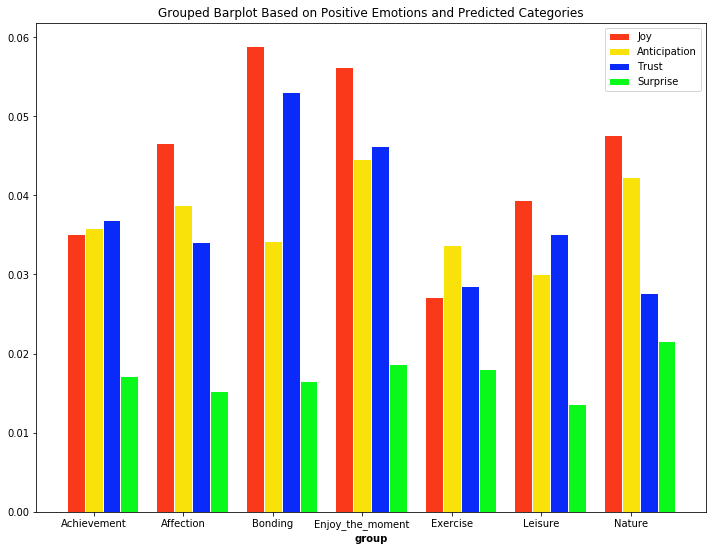

```python
barWidth = 0.20
plt.figure(figsize = (12,9))

bars1 = list(pos_cate["Joy"])
bars2 = list(pos_cate["Anticipation"])
bars3 = list(pos_cate["Trust"])
bars4 = list(pos_cate["Surprise"])

# Set position of bar on X axis
r1 = np.arange(len(bars1))
r2 = [x + barWidth for x in r1]
r3 = [x + barWidth for x in r2]
r4 = [x + barWidth for x in r3]

# Make the plot
plt.bar(r1, bars1, color='#FA381A', width=barWidth, edgecolor='white', label='Joy')
plt.bar(r2, bars2, color='#F9E10A', width=barWidth, edgecolor='white', label='Anticipation')
plt.bar(r3, bars3, color='#0A2AF9', width=barWidth, edgecolor='white', label='Trust')
plt.bar(r4, bars4, color='#0AF91A', width=barWidth, edgecolor='white', label='Surprise')

# Add xticks on the middle of the group bars
plt.xlabel('group', fontweight='bold')
plt.xticks([r + barWidth for r in range(len(bars1))], ['Achievement', 'Affection', 'Bonding', 'Enjoy_the_moment', 'Exercise', 'Leisure', 'Nature'])

# Create legend & Show graphic
plt.title("Grouped Barplot Based on Positive Emotions and Predicted Categories")
plt.legend()
plt.show()
```

## Step 6: Topic Analysis

I also want to take a look at the topics talked about in each category and to see if the topics align with some of my findings above. I first want to construct a LDA model with 10 topics based on the text of the whole data set and then take a look at the relatinoship between topics weights and categories.

```python
#construct a LDA model on text
def preprocess(doc,n):
    return(strip_short(remove_stopwords(strip_numeric(strip_punctuation(str(doc).lower()))),n).split())

lda_texts = [i for i in df["text"]]
corp = [preprocess(i,2) for i in lda_texts]
corp_dict = corpora.Dictionary(corp)
corp_dict.filter_extremes(no_below = 2, no_above = 0.97) #tags that appear at least 2 times and appear in no more than 97% of documents
corpus = [corp_dict.doc2bow(preprocess(i,2)) for i in lda_texts]
```

```python
lda_train_model = LdaModel(corpus=corpus,
                         id2word=corp_dict,
                         random_state=1,
                         num_topics=10,
                         passes=50,
                         chunksize=10000,
                         alpha='asymmetric',
                         decay=0.5,
                         offset=64,
                         eta=None,
                         eval_every=0,
                         iterations=80,
                         gamma_threshold=0.001,
                         per_word_topics=True)
```

Some findings about the topics by the LDA model:

The second topic seems to be related with happy moments when going to school.

The fourth topic seems to be related with happy moments working.

The ninth topic seems to be related with natural happy moments.

The tenth topic seems to be related with enjoying foods.

The vast majority topics here can be easily interpreted.

```python
lda_train_model.show_topics(num_topics = 10, formatted=False, num_words = 10)
```

```
[(0,
  [('time', 0.036702696),
   ('day', 0.029357994),
   ('friend', 0.028094964),
   ('home', 0.02133608),
   ('played', 0.020257771),
   ('night', 0.019810792),
   ('game', 0.015881015),
   ('nice', 0.013022319),
   ('wife', 0.012447071),
   ('birthday', 0.012255518)]),
 (1,
  [('friend', 0.03525561),
   ('day', 0.022346426),
   ('school', 0.021193678),
   ('time', 0.013409452),
   ('received', 0.01320421),
   ('talked', 0.013131115),
   ('college', 0.011014912),
   ('meet', 0.010066762),
   ('class', 0.009790211),
   ('called', 0.009705198)]),
 (2,
  [('moment', 0.064454585),
   ('life', 0.04032126),
   ('movie', 0.035499904),
   ('family', 0.032792542),
   ('time', 0.03230947),
   ('enjoyed', 0.02361735),
   ('finished', 0.022173386),
   ('project', 0.021142533),
   ('vacation', 0.019067734),
   ('person', 0.018342892)]),
 (3,
  [('job', 0.07483118),
   ('moved', 0.025881086),
   ('happiness', 0.020560946),
   ('offer', 0.016249256),
   ('positive', 0.014394519),
   ('company', 0.013747236),
```

[output cut: 55 more lines]

```
   ('film', 0.01643239),
   ('hike', 0.013460284),
   ('rain', 0.011050527),
   ('tree', 0.010846492)]),
 (9,
  [('dinner', 0.12095568),
   ('lunch', 0.06310201),
   ('eat', 0.051549677),
   ('food', 0.050624825),
   ('ate', 0.04849463),
   ('delicious', 0.037690237),
   ('restaurant', 0.0373117),
   ('cooked', 0.037169967),
   ('chicken', 0.015001298),
   ('family', 0.014524359)])]
```

Now, I want to get topic weights by each document or observation and add these values in the data set

```python
df["Topic 1"] = np.nan
df["Topic 2"] = np.nan
df["Topic 3"] = np.nan
df["Topic 4"] = np.nan
df["Topic 5"] = np.nan
df["Topic 6"] = np.nan
df["Topic 7"] = np.nan
df["Topic 8"] = np.nan
df["Topic 9"] = np.nan
df["Topic 10"] = np.nan
for i in range(0,df.shape[0]):
    corp_x = corp_dict.doc2bow(preprocess(df.iloc[i,10],2))
    topic_w = lda_train_model.get_document_topics(corp_x, minimum_probability = 0)
    for j in range(0,10):
        df.iloc[i,(11+j)] = topic_w[j][1]
```

To visualize the relatinoship between the topic weights and the categories of happy moments, I obtain the mean value of the topic weights for each topic by categories as following.

```python
topic_cate = df.groupby('predicted_category', as_index=False)[('Topic 1','Topic 2','Topic 3','Topic 4','Topic 5',
                                                              'Topic 6','Topic 7','Topic 8','Topic 9','Topic 10')].mean()
topic_cate
```

|  | predicted_category | Topic 1 | Topic 2 | Topic 3 | Topic 4 | Topic 5 | Topic 6 | Topic 7 | Topic 8 | Topic 9 | Topic 10 |
| --- | --- | --- | --- | --- | --- | --- | --- | --- | --- | --- | --- |
| 0 | achievement | 0.157197 | 0.244544 | 0.090674 | 0.110860 | 0.168186 | 0.068702 | 0.032631 | 0.052166 | 0.039322 | 0.035718 |
| 1 | affection | 0.462094 | 0.132507 | 0.082855 | 0.049085 | 0.061093 | 0.067522 | 0.035264 | 0.032000 | 0.025166 | 0.052413 |
| 2 | bonding | 0.354800 | 0.283035 | 0.081772 | 0.050430 | 0.045816 | 0.051645 | 0.040046 | 0.027025 | 0.022032 | 0.043400 |
| 3 | enjoy_the_moment | 0.285873 | 0.115807 | 0.101254 | 0.067366 | 0.072057 | 0.098419 | 0.061732 | 0.040852 | 0.036367 | 0.120274 |
| 4 | exercise | 0.219898 | 0.417937 | 0.087833 | 0.037309 | 0.033664 | 0.053684 | 0.024259 | 0.080411 | 0.025104 | 0.019902 |
| 5 | leisure | 0.285546 | 0.084392 | 0.129010 | 0.049717 | 0.069557 | 0.077359 | 0.139445 | 0.060264 | 0.059880 | 0.044830 |
| 6 | nature | 0.470660 | 0.049822 | 0.059825 | 0.034386 | 0.038580 | 0.070087 | 0.048583 | 0.041175 | 0.145929 | 0.040955 |

I further make the table into a heatmap as following. Some of the findings are:

Achievement seems to have higher weights on topic 4 and topic 5. It makes perfect sense, as topic 4 is about careers and work and topic 5 is about money and purchasing stuff.

Enjoy_the_moment seems to have higher weights on topic 6 and topic 10. Topic 6 contains a lot of works related to music and topic 10 contains words related to food. People tend to enjoy moments with music and food.

Leisure seems to have higher weights on topic 7 that is about traveling an watching movies.

Nature seems to have higher weights on topic 9 that is about nature and natural objects.

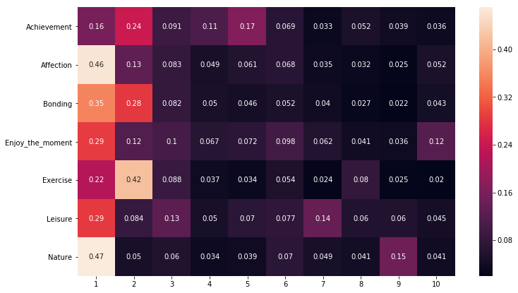

```python
Index= ['Achievement', 'Affection', 'Bonding', 'Enjoy_the_moment', 'Exercise', 'Leisure', 'Nature']
Cols = ['1', '2', '3', '4', '5', '6', '7', '8', '9', '10']
df = DataFrame(np.array(topic_cate.iloc[:,1:11]), index=Index, columns=Cols)
plt.figure(figsize = (12,7))
sns.heatmap(df, annot=True)
```

## Step 7: Conclusion

From the project, I learn that there is a distinct pattern for each of the category of happy moments. Specifically:

Achievement is about working, education and being successful.

Affection is about doing things with family.

Bonding is about doing things with people other than family.

Enjoy_the_moment can be a lot of things, but people tend to associate music and food with a happy moment.

Exercise is about exercising.

Leisure is about watching movies, playing video games and traveling.

Nature is about enjoying the natural environment.